# Untitled

Ik

3/29/2020

# Live vs. Studio

### Introduction

Up to this point, I’ve worked with the corpus on album level. This has as imiplication that I didn’t really have a fitting place to do some of the nice track-level visualizations and analyses I’ve learned during this course. However, Rush is also known for their very good live performances. So I decided to take one of the previously discussed epics, and see what makes these tracks so compelling live.

- Timbre features, deltas and deltadeltas
- Chroma features, deltas and deltadeltas
- Mean Interonset interval

Futhermore, I will also look at different types of hierearchial clustering algorithms, instead of using k-means. Using a hierarchical clustering methods will give us a more detailed view of how the studio albums correspond to each other.

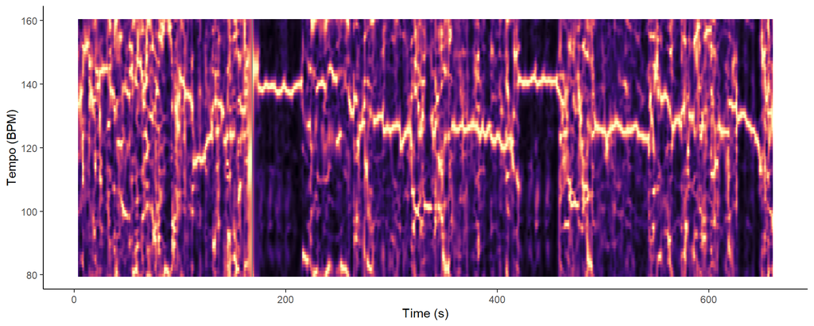

```r
load("data/xanadu_st_t.RData")
load("data/xanadu_live_t.RData")

xanadu_st_t
```

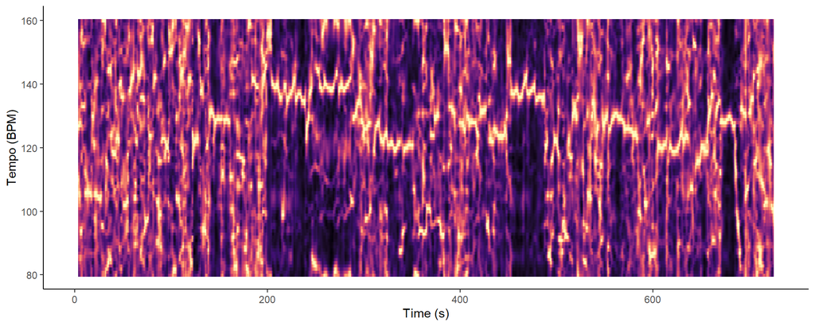

```r
xanadu_live_t
```